# BANA 7025 Final Project

Dontrell Johnson

2025-10-08

# Introduction

My final project seeks to answer the question: *Which customer demographic groups respond the most to certain coupon promotions on snack products?* I will complete a deep dive to see how effective coupons are across various customer demographics for a specific category. As CEO of Regork, retaining valuable customers is important, and those customers engaging with coupons are taking time to find deals within your stores. I hope to identify insights that will increase revenue through additional coupon usage.

I plan to address this problem through reviewing snacks transaction data for three different customer demographics: income, age, and household size.

Within my analysis, I expect that lower incomes will use more coupons to seek value in their purchases. I also expect that older age groups will utilize coupons to find cost savings. I also think that larger household sizes will utilize more coupons in their transactions.

# Setup

Below are the packages needed for this script.

```r
suppressWarnings(suppressMessages(library(completejourney)))
suppressWarnings(suppressMessages(library(tidyverse)))
```

First, I prepared the data sets from the *completejourney* package. I utilized the full demographics, products, transaction, and coupons data sets.

```r
demographics <- demographics
products <- products
transactions <- get_transactions()
coupons <- coupons
```

Next, I started by creating a new data frame *snacks* by joining the transactions and products data sets. I selected data with product_category names containing “SNACK” or “SNKS”. I then joined the new snacks data frame with demographics. I followed by joining it with coupons and creating a new column called coupon_used. After the *snacks* data set was assembled, I added a new column called “weekday” to identify when each transaction occurred.

```r
# create snacks by joining transactions with products and filtering on snack prod cats
snacks <- transactions %>%
  inner_join(products, by = "product_id") %>%
  filter(
      str_detect(product_category, regex("SNACK", ignore_case = TRUE)) |
      str_detect(product_category, regex("SNKS", ignore_case = TRUE))
  )

# join snacks with demographics
snacks <- snacks %>%
  inner_join(demographics, by = "household_id")

# join snacks with coupons and create coupon_used column
snacks <- snacks %>%
  left_join(coupons, by = "product_id", relationship = "many-to-many") %>%
  mutate(coupon_used = if_else(coupon_upc > 0, 'Yes', 'No', missing = 'No'))

# add weekday column
snacks <- snacks %>%
  mutate(weekday = wday(transaction_timestamp, label = TRUE, abbr = FALSE))
```

# Overview of Snack Category

This plot shows the 9 product categories that fall under snacks. It is clear that “Bag Snacks” is the most common product category for our data, followed by “Convenient Breakfast/Wholesome Snacks”. “Warehouse Snacks” and “Snack Nuts” are the other most common.

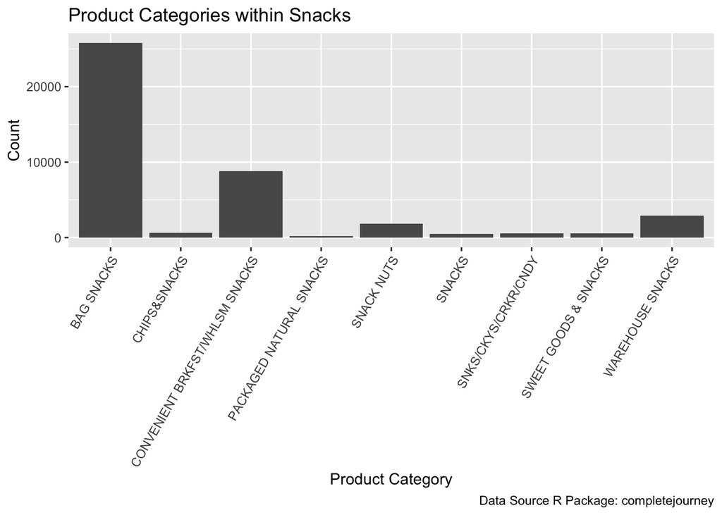

```r
snacks %>%
  ggplot(aes(x = product_category)) +
  geom_bar() +
  theme(axis.text.x = element_text(angle = 60, hjust = 1)) +
  labs(
    x = "Product Category",
    y = "Count",
    title = "Product Categories within Snacks",
    caption = "Data Source R Package: completejourney"
    )
```

# Income

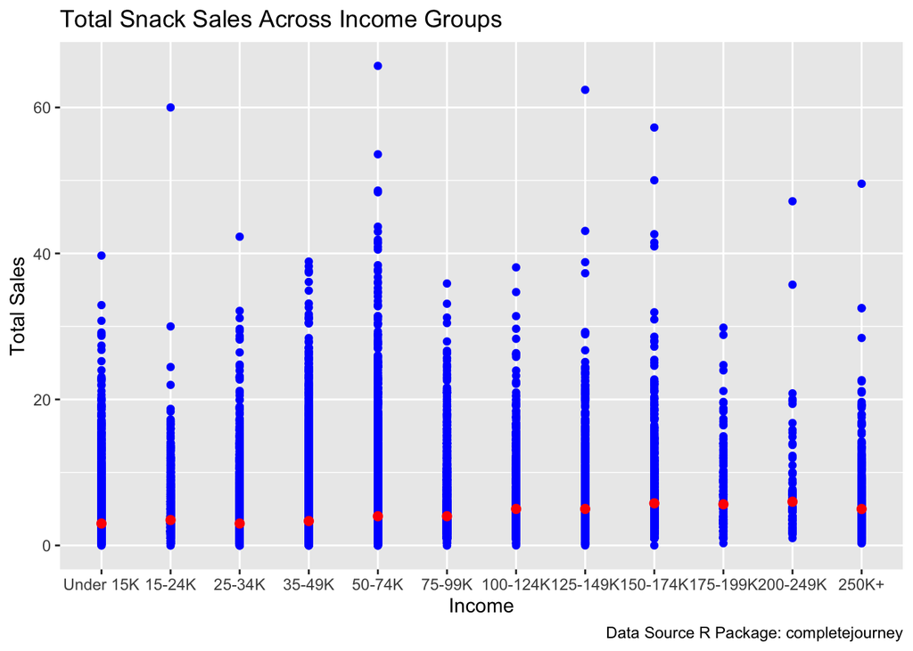

```r
snacks %>%
  group_by(income, basket_id) %>%
   summarize(total_sale = sum(sales_value), .groups = "drop") %>%
   ggplot(aes(income, total_sale)) +
   geom_point(color = "blue") +
   stat_summary(fun = "median", geom = "point", color = "red", size = 2) +
    labs(
    x = "Income",
    y = "Total Sales",
    title = "Total Snack Sales Across Income Groups",
    caption = "Data Source R Package: completejourney"
    )
```

I decided to look into coupon usage across income groups for the snack category. This plot identifies the breakdown between transactions where coupons were and were not used. As with the first plot, I see that the 50-74K income group purchases the greatest quantity of snacks, but primarily purchases without coupons. Across all income groups, coupons are underutilized and there is an opportunity to grow transaction volume with coupons.

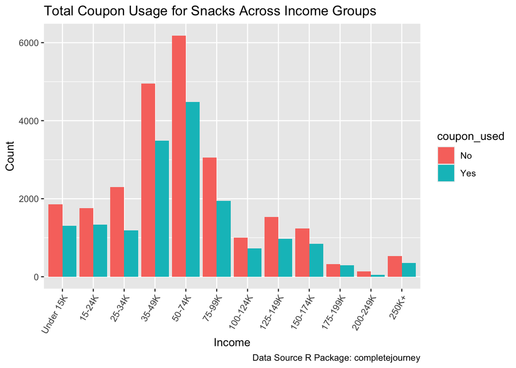

```r
ggplot(snacks, aes(x = income, fill = coupon_used)) +
  geom_bar(position = "dodge") +
  theme(axis.text.x = element_text(angle = 60, hjust = 1)) +
  labs(
    x = "Income",
    y = "Count",
    title = "Total Coupon Usage for Snacks Across Income Groups",
    caption = "Data Source R Package: completejourney"
    )
```

Now that I have seen coupon usage across income groups, my next step is to dive deeper into quantity of snacks purchased across the week, divided into transactions with and without coupons. Above 174K, the snack category and coupons for snacks are not frequently utilized. The 35-49K income group has relatively high purchase volume for snacks, and moderate coupon usage for snacks. To encourage coupon usage and drive transactions, continue to target snack coupons toward this group.

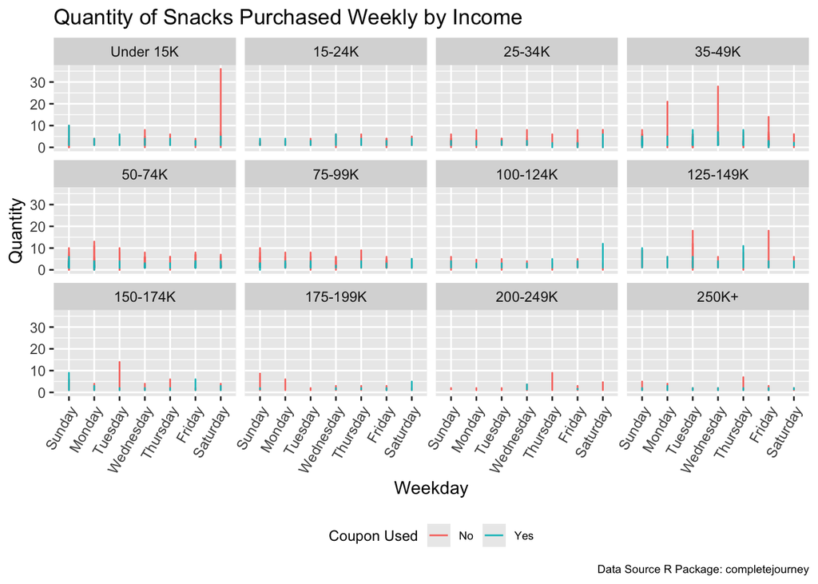

```r
snacks %>%
  arrange(coupon_used) %>%
  ggplot(aes(x = weekday, y = quantity, color = coupon_used)) +
  geom_line(data = snacks, aes(weekday, quantity)) +
  guides(color = guide_legend(title = "Coupon Used")) +
  scale_y_continuous() +
  theme(legend.justification = 'centre',
        legend.position = 'bottom',
        legend.direction = "horizontal",
        legend.key.height = unit(0.5, "cm"),
        legend.key.width = unit(0.5,"cm")) +
  labs(
    x = "Weekday",
    y = "Quantity",
    title = "Quantity of Snacks Purchased Weekly by Income",
    caption = "Data Source R Package: completejourney"
    ) +
  facet_wrap(~ income) +
  theme(
    plot.subtitle = element_text(face = "italic"),
    plot.caption = element_text(hjust = 1, size = 7),
    legend.title = element_text(size = 9),
    legend.text = element_text(size = 7),
    axis.text.x = element_text(angle = 60, hjust = 1)
  )
```

# Age

The plot below identifies the total sales for each age group across the snack category. Overall, snack purchases are concentrated within the 25-54 age groups. The 65+ age group purchases the fewest amount of snacks.

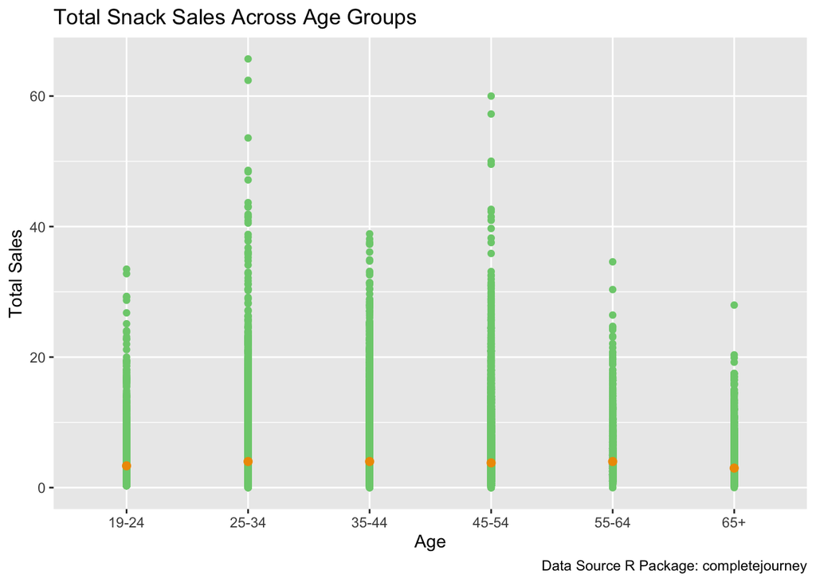

```r
snacks %>%
  group_by(age, basket_id) %>%
   summarize(total_sale = sum(sales_value), .groups = "drop") %>%
   ggplot(aes(age, total_sale)) +
   geom_point(color = "palegreen3") +
   stat_summary(fun = "median", geom = "point", color = "orange2", size = 2) +
  labs(
    x = "Age",
    y = "Total Sales",
    title = "Total Snack Sales Across Age Groups",
    caption = "Data Source R Package: completejourney"
    )
```

The next step is to dive into coupon usage across age groups for the snack category. This plot identifies the breakdown between transactions where coupons were and were not used. As with the first plot, I see that the 25-54 age group purchases the greatest quantity of snacks, but primarily purchases without coupons. The 19-24 age group may be more price-sensitive as they have the most balanced division of coupon and non-coupon purchases. Across all income groups, coupons are underutilized and there is an opportunity to grow transaction volume with coupons.

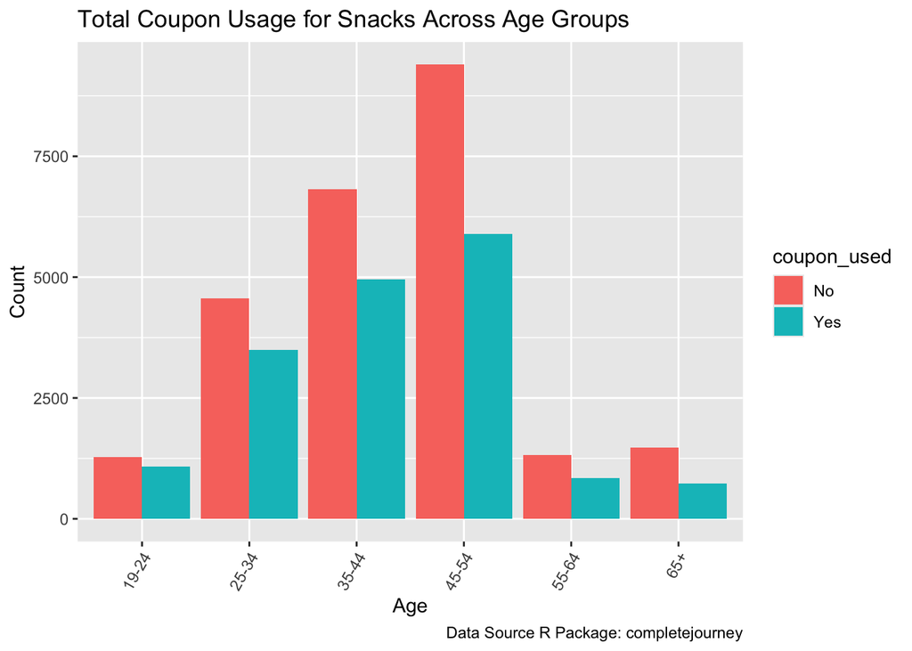

```r
ggplot(snacks, aes(x = age, fill = coupon_used)) +
  geom_bar(position = "dodge") +
  theme(axis.text.x = element_text(angle = 60, hjust = 1)) +
  labs(
    x = "Age",
    y = "Count",
    title = "Total Coupon Usage for Snacks Across Age Groups",
    caption = "Data Source R Package: completejourney"
    )
```

After I look at coupon usage across age groups, the next step is to investigate quantity of snacks purchased across the week, divided into transactions with and without coupons. The 35-44 and 45-54 age groups have high coupon usage on weekends, so this is an opportunity to provide more coupons to these groups on Saturday and Sunday. Within the 19-24 age group, there is a major spike of snack sales without coupons on Saturdays. This may be attributed to younger groups hanging out and purchasing snacks, especially without coupons. A targeted campaign to increase coupon usage in this group could provide savings to a group already making purchases.

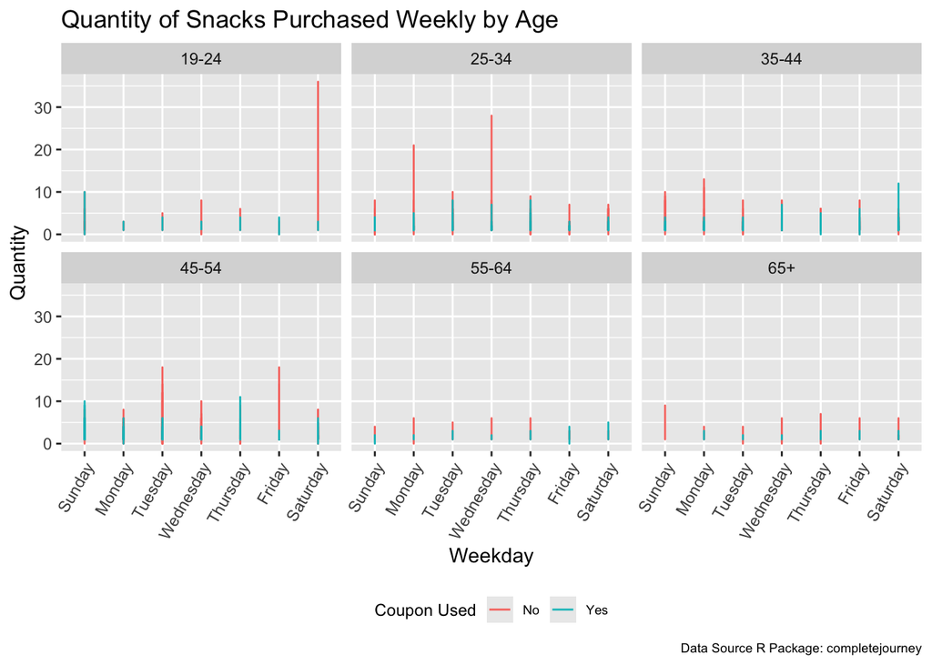

```r
snacks %>%
  arrange(coupon_used) %>%
  ggplot(aes(x = weekday, y = quantity, color = coupon_used)) +
  geom_line(data = snacks, aes(weekday, quantity)) +
  guides(color = guide_legend(title = "Coupon Used")) +
  scale_y_continuous() +
  theme(legend.justification = 'centre',
        legend.position = 'bottom',
        legend.direction = "horizontal",
        legend.key.height = unit(0.5, "cm"),
        legend.key.width = unit(0.5,"cm")) +
  labs(
    x = "Weekday",
    y = "Quantity",
    title = "Quantity of Snacks Purchased Weekly by Age",
    caption = "Data Source R Package: completejourney"
    ) +
  facet_wrap(~ age) +
  theme(
    plot.subtitle = element_text(face = "italic"),
    plot.caption = element_text(hjust = 1, size = 7),
    legend.title = element_text(size = 9),
    legend.text = element_text(size = 7),
    axis.text.x = element_text(angle = 60, hjust = 1)
  )
```

# Household Size

This plot details the total sales for each household size across the snack category. Overall, snack purchases are fairly well-balanced across household sizes, with most outliers occurring in households with 2 people.

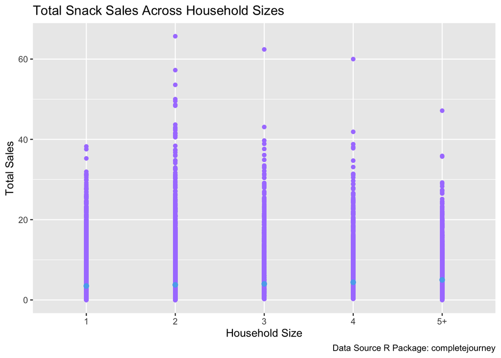

```r
snacks %>%
  group_by(household_size, basket_id) %>%
   summarize(total_sale = sum(sales_value), .groups = "drop") %>%
   ggplot(aes(household_size, total_sale)) +
   geom_point(color = "mediumpurple1") +
   stat_summary(fun = "median", geom = "point", color = "steelblue2", size = 2) +
   labs(
    x = "Household Size",
    y = "Total Sales",
    title = "Total Snack Sales Across Household Sizes",
    caption = "Data Source R Package: completejourney"
    )
```

Next, I will explore coupon usage across household sizes for the snack category. This plot identifies the breakdown between transactions where coupons were and were not used. As with the first plot, I see that households of 2 purchase the greatest quantity of snacks, but primarily purchase without coupons. Households of 4 purchase the least amount of snacks, but have a more balanced assortment of coupon and non-coupon purchases. Across all household sizes, coupons are underutilized and there is an opportunity to grow transaction volume with coupons.

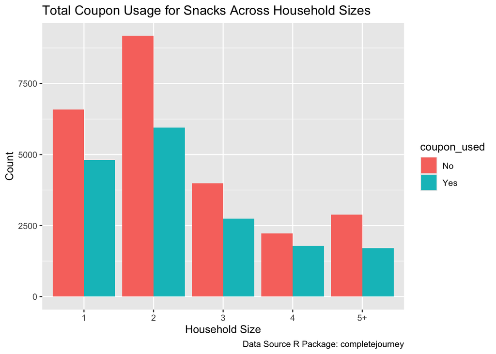

```r
ggplot(snacks, aes(x = household_size, fill = coupon_used)) +
  geom_bar(position = "dodge") +
   labs(
    x = "Household Size",
    y = "Count",
    title = "Total Coupon Usage for Snacks Across Household Sizes",
    caption = "Data Source R Package: completejourney"
    )
```

After I look at coupon usage across household sizes, the next step is to investigate quantity of snacks purchased across the week, divided into transactions with and without coupons. Households of 2 have balanced coupon usage across the week, so this is an opportunity to provide even more coupons to these groups to encourage their consistent spending. Within the household size of 1, like the 19-24 age group, there is a major spike of snack sales without coupons on Saturdays. This may be attributed to individual, younger households purchasing snacks for weekend activities, especially without coupons. A targeted campaign to increase coupon usage in this group could provide savings to a group already making purchases.

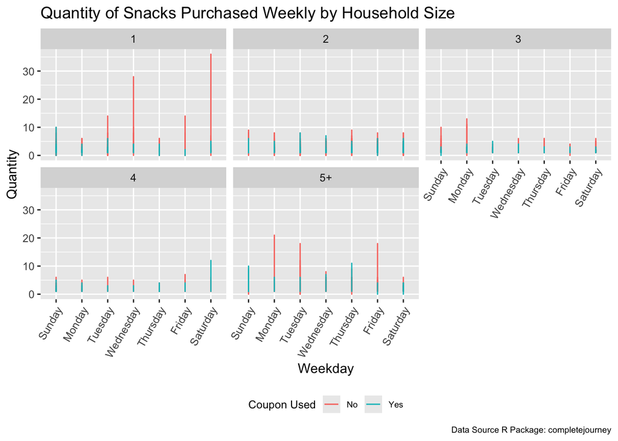

```r
snacks %>%
  arrange(coupon_used) %>%
  ggplot(aes(x = weekday, y = quantity, color = coupon_used)) +
  geom_line(data = snacks, aes(weekday, quantity)) +
  guides(color = guide_legend(title = "Coupon Used")) +
  scale_y_continuous() +
  theme(legend.justification = 'centre',
        legend.position = 'bottom',
        legend.direction = "horizontal",
        legend.key.height = unit(0.5, "cm"),
        legend.key.width = unit(0.5,"cm")) +
  labs(
    x = "Weekday",
    y = "Quantity",
    title = "Quantity of Snacks Purchased Weekly by Household Size",
    caption = "Data Source R Package: completejourney"
    ) +
  facet_wrap(~ household_size) +
  theme(
    plot.subtitle = element_text(face = "italic"),
    plot.caption = element_text(hjust = 1, size = 7),
    legend.title = element_text(size = 9),
    legend.text = element_text(size = 7),
    axis.text.x = element_text(angle = 60, hjust = 1)
  )
```

# Summary

My final project sought to answer the question: *Which customer demographic groups respond the most to certain coupon promotions on snack products?* I wanted to do a deep dive to see how effective coupons are across various customer demographics for a specific category. As CEO of Regork, retaining valuable customers is important, and those customers engaging with coupons are taking time to find deals within your stores. I hope to identify insights that will increase revenue through additional coupon usage.

I addressed this problem through reviewing snacks transaction data for three different customer demographics: income, age, and household size.

Based on my analysis, my recommendation is twofold: first, avoid targeting snack coupons toward higher income and older age groups, as they do not purchase large amounts of snacks. Additionally, focus on key snack sale spikes throughout the week, particularly within younger age groups and smaller households, as these are strong opportunities to provide coupons and capitalize on existing snack sales to provide value to customers and drive higher revenue.